# Dodgers Attendance Analysis – 2022 Season

This analysis explores the factors influencing attendance at Los Angeles Dodgers home games in the 2022 season. The goal is to provide actionable recommendations to increase fan turnout.

```python
import pandas as pd
import matplotlib.pyplot as plt
import seaborn as sns

# Load the data
dodgers_df = pd.read_csv('/Users/bryanemer/Downloads/dodgers-2022.csv')
dodgers_df.head()
```

|  | month | day | attend | day_of_week | opponent | temp | skies | day_night | cap | shirt | fireworks | bobblehead |
| --- | --- | --- | --- | --- | --- | --- | --- | --- | --- | --- | --- | --- |
| 0 | APR | 10 | 56000 | Tuesday | Pirates | 67 | Clear | Day | NO | NO | NO | NO |
| 1 | APR | 11 | 29729 | Wednesday | Pirates | 58 | Cloudy | Night | NO | NO | NO | NO |
| 2 | APR | 12 | 28328 | Thursday | Pirates | 57 | Cloudy | Night | NO | NO | NO | NO |
| 3 | APR | 13 | 31601 | Friday | Padres | 54 | Cloudy | Night | NO | NO | YES | NO |
| 4 | APR | 14 | 46549 | Saturday | Padres | 57 | Cloudy | Night | NO | NO | NO | NO |

The dataset includes 81 home games for the Dodgers' 2022 season, including the following features:

- Date and weather: month, day, temp, skies, day_night
- Opponent and schedule: day_of_week, opponent
- Promotions: cap, shirt, fireworks, bobblehead
- Attendance: attend

In order to provide a recommendation for improving attendance, I will explore attendance patterns based on different factors, visualize key trends, and summarize insights to make my final recommendation.

## Attendance by Day of the Week

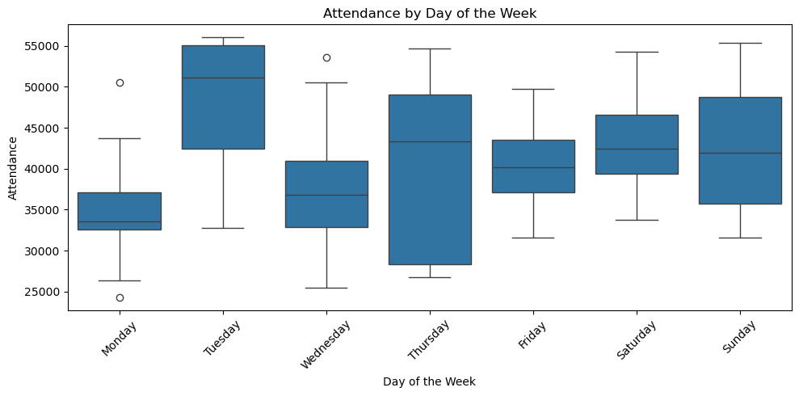

```python
plt.figure(figsize=(10, 5))
sns.boxplot(x="day_of_week", y="attend", data=dodgers_df,
            order=["Monday", "Tuesday", "Wednesday", "Thursday", "Friday", "Saturday", "Sunday"])
plt.title("Attendance by Day of the Week")
plt.ylabel("Attendance")
plt.xlabel("Day of the Week")
plt.xticks(rotation=45)
plt.tight_layout()
plt.show()
```

## Attendance and Promotional Events

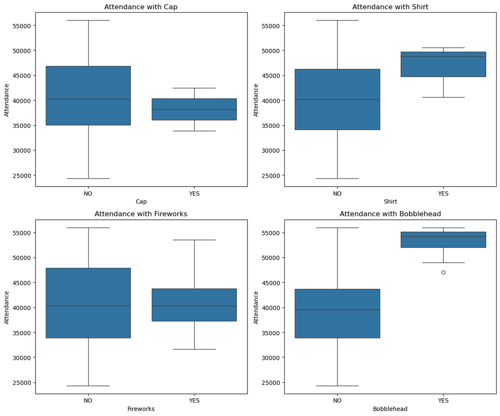

```python
promo_features = ['cap', 'shirt', 'fireworks', 'bobblehead']
fig, axes = plt.subplots(2, 2, figsize=(12, 10))
axes = axes.flatten()
for i, feature in enumerate(promo_features):
    sns.boxplot(x=feature, y="attend", data=dodgers_df, ax=axes[i])
    axes[i].set_title(f"Attendance with {feature.capitalize()}")
    axes[i].set_ylabel("Attendance")
    axes[i].set_xlabel(f"{feature.capitalize()}")
plt.tight_layout()
plt.show()
```

From the data we can see that while cap giveaways and fireworks do not seem to have much impact on attendance, we see higher average attendance with shirt giveaways and particularly bobblehead giveaways.

## Top Opponents and Game Timing

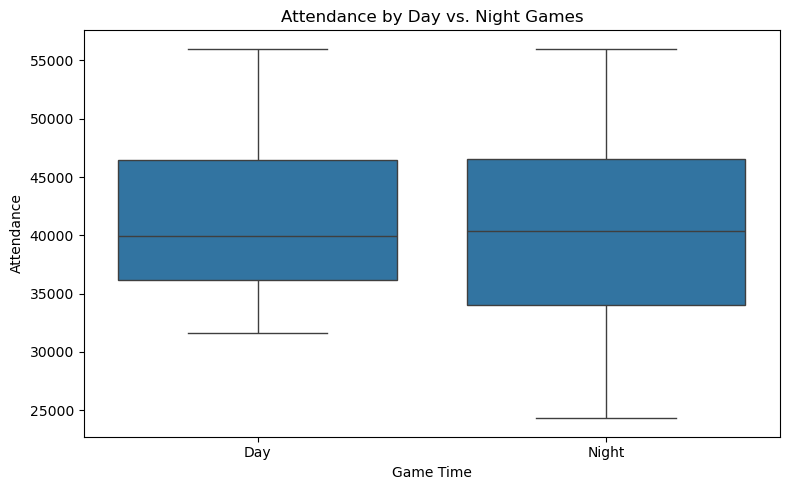

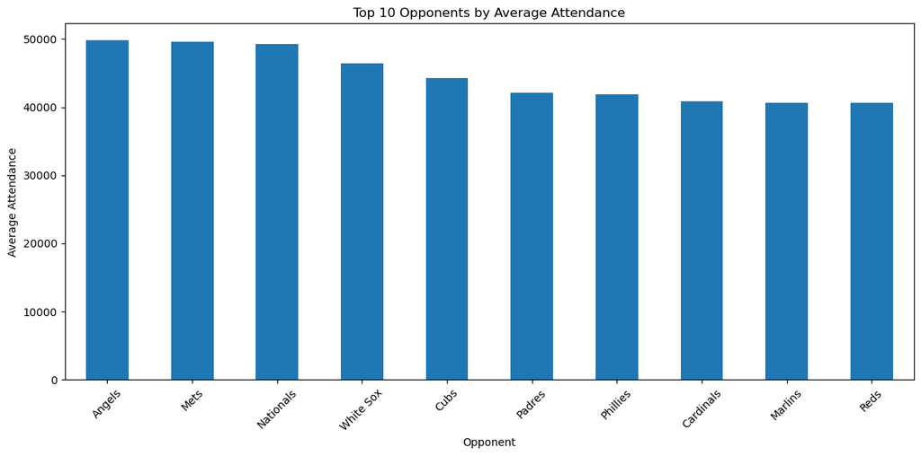

```python
top_opponents = dodgers_df.groupby("opponent")["attend"].mean().sort_values(ascending=False)

plt.figure(figsize=(8, 5))
sns.boxplot(x="day_night", y="attend", data=dodgers_df)
plt.title("Attendance by Day vs. Night Games")
plt.ylabel("Attendance")
plt.xlabel("Game Time")
plt.tight_layout()
plt.show()

plt.figure(figsize=(12, 6))
top_opponents.head(10).plot(kind='bar')
plt.title("Top 10 Opponents by Average Attendance")
plt.ylabel("Average Attendance")
plt.xlabel("Opponent")
plt.xticks(rotation=45)
plt.tight_layout()
plt.show()
```

We see here that night games have slightly higher attendance on average, although not by much. The top 3 opponents by average attendance are the Angels, the Mets, and the Nationals.

## Weather Impact

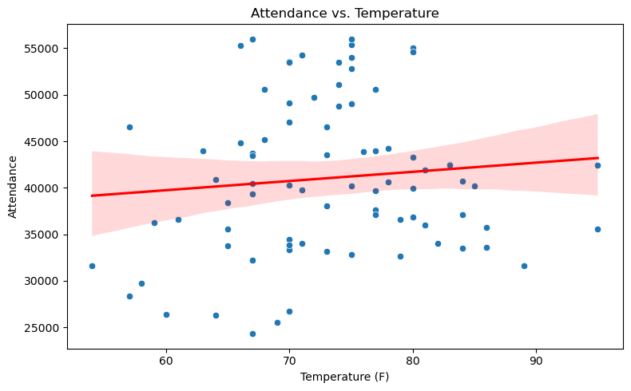

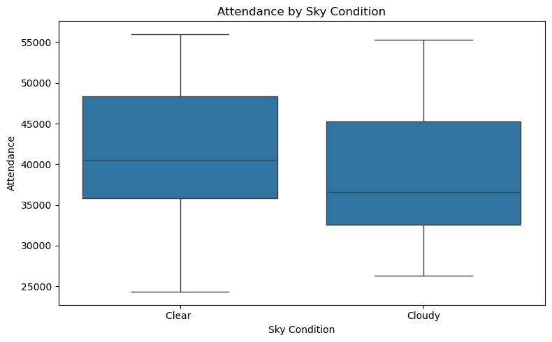

```python
plt.figure(figsize=(8, 5))
sns.scatterplot(x="temp", y="attend", data=dodgers_df)
sns.regplot(x="temp", y="attend", data=dodgers_df, scatter=False, color='red')
plt.title("Attendance vs. Temperature")
plt.xlabel("Temperature (F)")
plt.ylabel("Attendance")
plt.tight_layout()
plt.show()

plt.figure(figsize=(8, 5))
sns.boxplot(x="skies", y="attend", data=dodgers_df)
plt.title("Attendance by Sky Condition")
plt.xlabel("Sky Condition")
plt.ylabel("Attendance")
plt.tight_layout()
plt.show()
```

There is a slight positive correlation between temperature and attendance, suggesting that warmer days have higher attendance. More significant than this however is the difference in attendance between clear and cloudy days, with clear days having much higher average attendance.

## Linear Regression and Random Forest Regressor

```python
from sklearn.model_selection import train_test_split
from sklearn.linear_model import LinearRegression
from sklearn.ensemble import RandomForestRegressor
from sklearn.metrics import mean_absolute_error, r2_score
from sklearn.preprocessing import OneHotEncoder
from sklearn.compose import ColumnTransformer
from sklearn.pipeline import Pipeline

# Prepare features and target
X = dodgers_df.drop(columns=["attend", "day", "month"])
y = dodgers_df["attend"]

categorical_cols = X.select_dtypes(include=["object"]).columns.tolist()
numerical_cols = X.select_dtypes(include=["int64"]).columns.tolist()

preprocessor = ColumnTransformer([
    ("cat", OneHotEncoder(drop="first"), categorical_cols),
    ("num", "passthrough", numerical_cols)
])

lr_pipeline = Pipeline([
    ("preprocessor", preprocessor),
    ("model", LinearRegression())
])

rf_pipeline = Pipeline([
    ("preprocessor", preprocessor),
    ("model", RandomForestRegressor(random_state=42, n_estimators=100))
])

X_train, X_test, y_train, y_test = train_test_split(X, y, test_size=0.2)

# Fit and predict
lr_pipeline.fit(X_train, y_train)
lr_preds = lr_pipeline.predict(X_test)

rf_pipeline.fit(X_train, y_train)
rf_preds = rf_pipeline.predict(X_test)

# Evaluation
lr_mae = mean_absolute_error(y_test, lr_preds)
lr_r2 = r2_score(y_test, lr_preds)

rf_mae = mean_absolute_error(y_test, rf_preds)
rf_r2 = r2_score(y_test, rf_preds)

print("Linear Regression - MAE:", round(lr_mae, 2), "R²:", round(lr_r2, 3))
print("Random Forest - MAE:", round(rf_mae, 2), "R²:", round(rf_r2, 3))
```

```
Linear Regression - MAE: 6828.43 R²: 0.278
Random Forest - MAE: 7493.96 R²: 0.217
```

Here I attempted to fit both a Linear Regression model and a Random Forest regressor to predict the attendance from the data. The Linear Regression model had an R2 of 0.278, and the Random Forest regressor had an R2 of 0.217, suggesting that neither model is a particularly good fit for predicting attendance.

## Source

Los Angeles Dodgers MLB Attendance Data - Provided on Blackboard by instructor https://cyberactive.bellevue.edu/ultra/courses/_538531_1/cl/outline